# Titanic Class-Survival Gap: Access and Constraints vs. Priority Rules

# 4. Decomposition Analysis

## 4.1 Survival by Gender and Class (Priority Rule Interaction)

```r
# Survival rates by gender and class
gender_class_survival <- train %>%
  group_by(Pclass, Sex) %>%
  summarise(
    N = n(),
    Survived_Count = sum(Survived),
    Survival_Rate = mean(Survived),
    .groups = 'drop'
  ) %>%
  mutate(
    Pclass = factor(Pclass, labels = c("1st Class", "2nd Class", "3rd Class"))
  )

print(kable(gender_class_survival,
            caption = "Survival Rates by Gender and Class",
            digits = 3))
```

```
Table: Survival Rates by Gender and Class

|Pclass    |Sex    |   N| Survived_Count| Survival_Rate|
|:---------|:------|---:|--------------:|-------------:|
|1st Class |female |  94|             91|         0.968|
|1st Class |male   | 122|             45|         0.369|
|2nd Class |female |  76|             70|         0.921|
|2nd Class |male   | 108|             17|         0.157|
|3rd Class |female | 144|             72|         0.500|
|3rd Class |male   | 347|             47|         0.135|
```

```r
# Extract key rates
female_1st <- gender_class_survival %>% filter(Pclass == "1st Class", Sex == "female") %>% pull(Survival_Rate)
male_1st <- gender_class_survival %>% filter(Pclass == "1st Class", Sex == "male") %>% pull(Survival_Rate)
female_3rd <- gender_class_survival %>% filter(Pclass == "3rd Class", Sex == "female") %>% pull(Survival_Rate)
male_3rd <- gender_class_survival %>% filter(Pclass == "3rd Class", Sex == "male") %>% pull(Survival_Rate)

gender_effect_1st <- female_1st - male_1st
gender_effect_3rd <- female_3rd - male_3rd
```

**Explanation**: The priority rule effect manifests clearly in gender-specific survival rates. For 1st class, women had a survival rate of 0.968 versus men at 0.369, a priority advantage of 0.599. For 3rd class, women had 0.5 versus men at 0.135, an advantage of 0.365. Notably, the priority rule advantage was *weaker* in 3rd class (0.365 vs. 0.599), suggesting that class-based access constraints may have partially overridden the gender-priority protocol. For women (who should have had highest priority), 3rd class women survived at 0.5 compared to 1st class women at 0.968, still a substantial gap. This indicates that even accounting for priority rules, structural access differences between classes significantly affected outcomes.

## 4.2 Visualization: Gender-Class Interaction

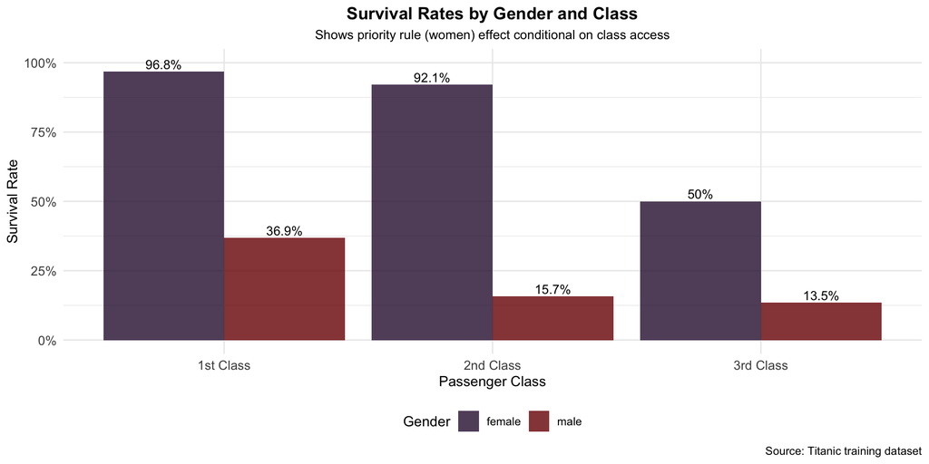

```r
gender_class_plot <- gender_class_survival %>%
  ggplot(aes(x = Pclass, y = Survival_Rate, fill = Sex, group = Sex)) +
  geom_col(position = "dodge", alpha = 0.8) +
  geom_text(aes(label = paste0(round(Survival_Rate * 100, 1), "%")),
            position = position_dodge(width = 0.9),
            vjust = -0.3, size = 3.5) +
  scale_fill_viridis_d(option = "turbo") +
  scale_y_continuous(limits = c(0, 1), labels = scales::percent) +
  labs(
    title = "Survival Rates by Gender and Class",
    subtitle = "Shows priority rule (women) effect conditional on class access",
    x = "Passenger Class",
    y = "Survival Rate",
    fill = "Gender",
    caption = "Source: Titanic training dataset"
  ) +
  theme_minimal() +
  theme(
    plot.title = element_text(hjust = 0.5, face = "bold"),
    plot.subtitle = element_text(hjust = 0.5, size = 10),
    axis.text = element_text(size = 10),
    legend.position = "bottom"
  )

print(gender_class_plot)
```

**Explanation**: This visualization reveals the interaction between priority rules (women-first) and access constraints (class location). Within each gender, we see substantial class gaps: 1st class women had 96.8% survival compared to 50% for 3rd class women—a 46.8 percentage point gap even among the priority-favored demographic. Similarly, men show class gaps. This pattern illustrates that class-based access constraints are *not entirely overcome* by priority rules—even women, the most prioritized group, experienced substantial class-based disadvantage, indicating that physical cabin location and evacuation route constraints in 3rd class were severe enough to counteract official priority protocols.

## 4.3 Survival by Age and Class

```r
# Create age groups for better visualization
train_age <- train %>%
  filter(!is.na(Age)) %>%
  mutate(
    Age_Group = case_when(
      Age < 13 ~ "Child (< 13)",
      Age >= 13 & Age < 65 ~ "Adult (13-64)",
      Age >= 65 ~ "Elderly (65+)"
    )
  )

age_class_survival <- train_age %>%
  group_by(Pclass, Age_Group) %>%
  summarise(
    N = n(),
    Survived_Count = sum(Survived),
    Survival_Rate = mean(Survived),
    .groups = 'drop'
  ) %>%
  mutate(
    Pclass = factor(Pclass, labels = c("1st Class", "2nd Class", "3rd Class")),
    Age_Group = factor(Age_Group, levels = c("Child (< 13)", "Adult (13-64)", "Elderly (65+)"))
  )

print(kable(age_class_survival,
            caption = "Survival Rates by Age Group and Class",
            digits = 3))
```

```
Table: Survival Rates by Age Group and Class

|Pclass    |Age_Group     |   N| Survived_Count| Survival_Rate|
|:---------|:-------------|---:|--------------:|-------------:|
|1st Class |Adult (13-64) | 176|            118|         0.670|
|1st Class |Child (< 13)  |   4|              3|         0.750|
|1st Class |Elderly (65+) |   6|              1|         0.167|
|2nd Class |Adult (13-64) | 154|             66|         0.429|
|2nd Class |Child (< 13)  |  17|             17|         1.000|
|2nd Class |Elderly (65+) |   2|              0|         0.000|
|3rd Class |Adult (13-64) | 304|             65|         0.214|
|3rd Class |Child (< 13)  |  48|             20|         0.417|
|3rd Class |Elderly (65+) |   3|              0|         0.000|
```

```r
# Extract child survival rates
child_1st <- age_class_survival %>% filter(Pclass == "1st Class", Age_Group == "Child (< 13)") %>% pull(Survival_Rate)
child_3rd <- age_class_survival %>% filter(Pclass == "3rd Class", Age_Group == "Child (< 13)") %>% pull(Survival_Rate)
child_gap <- child_1st - child_3rd
```

**Explanation**: Children were prioritized in the evacuation protocol alongside women. However, we observe that 1st class children had a survival rate of 0.75 versus 3rd class children at 0.417, a gap of 0.333 or 33.3 percentage points. This is substantial—even among the highest-priority group (children), class made a critical difference in survival outcomes. The fact that the priority rule advantage (favoring children) did not fully equalize outcomes across classes provides strong evidence that access and constraint factors (cabin location, evacuation route, communication) were powerful determinants of survival, capable of overriding formal evacuation protocols.

## 4.4 Visualization: Age Group and Class

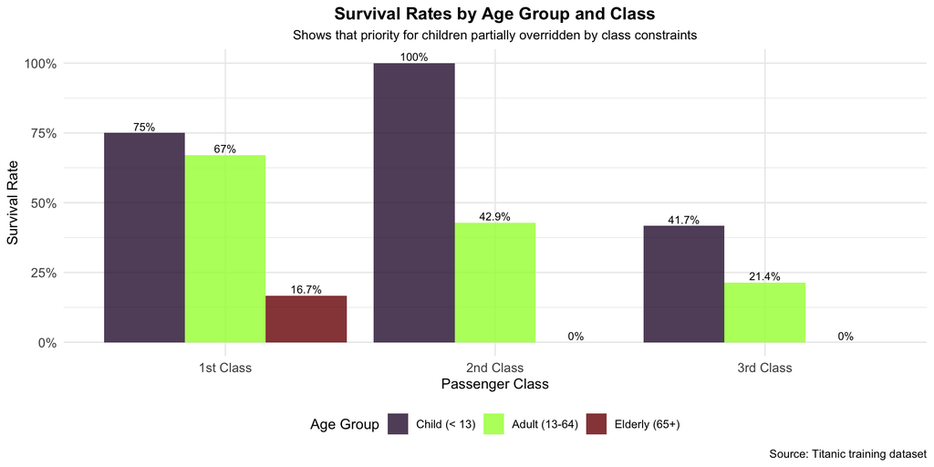

```r
age_class_plot <- age_class_survival %>%
  ggplot(aes(x = Pclass, y = Survival_Rate, fill = Age_Group, group = Age_Group)) +
  geom_col(position = "dodge", alpha = 0.8) +
  geom_text(aes(label = paste0(round(Survival_Rate * 100, 1), "%")),
            position = position_dodge(width = 0.9),
            vjust = -0.3, size = 3) +
  scale_fill_viridis_d(option = "turbo") +
  scale_y_continuous(limits = c(0, 1), labels = scales::percent) +
  labs(
    title = "Survival Rates by Age Group and Class",
    subtitle = "Shows that priority for children partially overridden by class constraints",
    x = "Passenger Class",
    y = "Survival Rate",
    fill = "Age Group",
    caption = "Source: Titanic training dataset"
  ) +
  theme_minimal() +
  theme(
    plot.title = element_text(hjust = 0.5, face = "bold"),
    plot.subtitle = element_text(hjust = 0.5, size = 10),
    axis.text = element_text(size = 10),
    legend.position = "bottom"
  )

print(age_class_plot)
```